# Risk Factor Analysis

## Outcome Variable

**Outcome Variable:** y_rate_len

## Predictor Variables

**Intervention Variable:** perdiar6

**Adjustment Set:**

- arm
- sex
- W_mage
- meducyrs
- feducyrs
- hfoodsec
- W_mhtcm
- W_mwtkg
- W_mbmi
- W_birthwt
- W_birthlen
- W_nrooms
- month
- brthmon
- impfloor
- impsan
- safeh20
- delta_W_mage
- delta_meducyrs
- delta_feducyrs
- delta_hfoodsec
- delta_W_mhtcm
- delta_W_mwtkg
- delta_W_mbmi
- delta_W_birthwt
- delta_W_birthlen
- delta_W_nrooms
- delta_month
- delta_brthmon
- delta_impfloor
- delta_impsan
- delta_safeh20

## Stratifying Variables

The analysis was stratified on these variable(s):

- agecat
- studyid
- country

## Data Summary

| agecat | studyid | country | perdiar6 | n_cell | n |
| --- | --- | --- | --- | --- | --- |
| 0-3 months | ki0047075b-MAL-ED | BANGLADESH | Q1 | 243 | 244 |
| 0-3 months | ki0047075b-MAL-ED | BANGLADESH | Q2 | 1 | 244 |
| 0-3 months | ki1017093-NIH-Birth | BANGLADESH | Q1 | 554 | 566 |
| 0-3 months | ki1017093-NIH-Birth | BANGLADESH | Q2 | 12 | 566 |
| 0-3 months | ki1017093b-PROVIDE | BANGLADESH | Q1 | 629 | 634 |
| 0-3 months | ki1017093b-PROVIDE | BANGLADESH | Q2 | 5 | 634 |
| 0-3 months | ki1017093c-NIH-Crypto | BANGLADESH | Q1 | 716 | 720 |
| 0-3 months | ki1017093c-NIH-Crypto | BANGLADESH | Q2 | 4 | 720 |
| 0-3 months | ki1114097-CMIN | BANGLADESH | Q1 | 41 | 43 |
| 0-3 months | ki1114097-CMIN | BANGLADESH | Q2 | 2 | 43 |
| 0-3 months | ki0047075b-MAL-ED | BRAZIL | Q1 | 180 | 180 |
| 0-3 months | ki1114097-CMIN | BRAZIL | Q1 | 81 | 81 |
| 0-3 months | ki1114097-CMIN | GUINEA-BISSAU | Q1 | 21 | 21 |
| 0-3 months | ki0047075b-MAL-ED | INDIA | Q1 | 200 | 201 |
| 0-3 months | ki0047075b-MAL-ED | INDIA | Q2 | 1 | 201 |
| 0-3 months | ki0047075b-MAL-ED | NEPAL | Q1 | 172 | 175 |
| 0-3 months | ki0047075b-MAL-ED | NEPAL | Q2 | 3 | 175 |
| 0-3 months | ki1000109-ResPak | PAKISTAN | Q1 | 73 | 78 |
| 0-3 months | ki1000109-ResPak | PAKISTAN | Q2 | 5 | 78 |
| 0-3 months | ki0047075b-MAL-ED | PERU | Q1 | 266 | 271 |
| 0-3 months | ki0047075b-MAL-ED | PERU | Q2 | 5 | 271 |
| 0-3 months | ki1114097-CMIN | PERU | Q1 | 88 | 93 |
| 0-3 months | ki1114097-CMIN | PERU | Q2 | 5 | 93 |
| 0-3 months | ki1114097-CONTENT | PERU | Q1 | 29 | 29 |
| 0-3 months | ki0047075b-MAL-ED | SOUTH AFRICA | Q1 | 229 | 229 |
| 0-3 months | ki0047075b-MAL-ED | TANZANIA, UNITED REPUBLIC OF | Q1 | 229 | 229 |
| 3-6 months | ki0047075b-MAL-ED | BANGLADESH | Q1 | 230 | 231 |
| 3-6 months | ki0047075b-MAL-ED | BANGLADESH | Q2 | 1 | 231 |
| 3-6 months | ki1017093-NIH-Birth | BANGLADESH | Q1 | 516 | 523 |
| 3-6 months | ki1017093-NIH-Birth | BANGLADESH | Q2 | 7 | 523 |

[output cut: 83 more lines]

The following strata were considered:

- agecat: 0-3 months, studyid: ki0047075b-MAL-ED, country: BANGLADESH
- agecat: 0-3 months, studyid: ki0047075b-MAL-ED, country: BRAZIL
- agecat: 0-3 months, studyid: ki0047075b-MAL-ED, country: INDIA
- agecat: 0-3 months, studyid: ki0047075b-MAL-ED, country: NEPAL
- agecat: 0-3 months, studyid: ki0047075b-MAL-ED, country: PERU
- agecat: 0-3 months, studyid: ki0047075b-MAL-ED, country: SOUTH AFRICA
- agecat: 0-3 months, studyid: ki0047075b-MAL-ED, country: TANZANIA, UNITED REPUBLIC OF
- agecat: 0-3 months, studyid: ki1000109-ResPak, country: PAKISTAN
- agecat: 0-3 months, studyid: ki1017093-NIH-Birth, country: BANGLADESH
- agecat: 0-3 months, studyid: ki1017093b-PROVIDE, country: BANGLADESH
- agecat: 0-3 months, studyid: ki1017093c-NIH-Crypto, country: BANGLADESH
- agecat: 0-3 months, studyid: ki1114097-CMIN, country: BANGLADESH
- agecat: 0-3 months, studyid: ki1114097-CMIN, country: BRAZIL
- agecat: 0-3 months, studyid: ki1114097-CMIN, country: GUINEA-BISSAU
- agecat: 0-3 months, studyid: ki1114097-CMIN, country: PERU
- agecat: 0-3 months, studyid: ki1114097-CONTENT, country: PERU
- agecat: 12-24 months, studyid: ki0047075b-MAL-ED, country: BANGLADESH
- agecat: 12-24 months, studyid: ki0047075b-MAL-ED, country: BRAZIL
- agecat: 12-24 months, studyid: ki0047075b-MAL-ED, country: INDIA
- agecat: 12-24 months, studyid: ki0047075b-MAL-ED, country: NEPAL
- agecat: 12-24 months, studyid: ki0047075b-MAL-ED, country: PERU
- agecat: 12-24 months, studyid: ki0047075b-MAL-ED, country: SOUTH AFRICA
- agecat: 12-24 months, studyid: ki0047075b-MAL-ED, country: TANZANIA, UNITED REPUBLIC OF
- agecat: 12-24 months, studyid: ki1017093-NIH-Birth, country: BANGLADESH
- agecat: 12-24 months, studyid: ki1017093b-PROVIDE, country: BANGLADESH
- agecat: 12-24 months, studyid: ki1017093c-NIH-Crypto, country: BANGLADESH
- agecat: 12-24 months, studyid: ki1114097-CMIN, country: BANGLADESH
- agecat: 12-24 months, studyid: ki1114097-CMIN, country: GUINEA-BISSAU
- agecat: 12-24 months, studyid: ki1114097-CMIN, country: PERU
- agecat: 12-24 months, studyid: ki1114097-CONTENT, country: PERU
- agecat: 3-6 months, studyid: ki0047075b-MAL-ED, country: BANGLADESH
- agecat: 3-6 months, studyid: ki0047075b-MAL-ED, country: BRAZIL
- agecat: 3-6 months, studyid: ki0047075b-MAL-ED, country: INDIA
- agecat: 3-6 months, studyid: ki0047075b-MAL-ED, country: NEPAL
- agecat: 3-6 months, studyid: ki0047075b-MAL-ED, country: PERU
- agecat: 3-6 months, studyid: ki0047075b-MAL-ED, country: SOUTH AFRICA
- agecat: 3-6 months, studyid: ki0047075b-MAL-ED, country: TANZANIA, UNITED REPUBLIC OF
- agecat: 3-6 months, studyid: ki1000109-ResPak, country: PAKISTAN
- agecat: 3-6 months, studyid: ki1017093-NIH-Birth, country: BANGLADESH
- agecat: 3-6 months, studyid: ki1017093b-PROVIDE, country: BANGLADESH
- agecat: 3-6 months, studyid: ki1017093c-NIH-Crypto, country: BANGLADESH
- agecat: 3-6 months, studyid: ki1114097-CMIN, country: BANGLADESH
- agecat: 3-6 months, studyid: ki1114097-CMIN, country: BRAZIL
- agecat: 3-6 months, studyid: ki1114097-CMIN, country: GUINEA-BISSAU
- agecat: 3-6 months, studyid: ki1114097-CMIN, country: PERU
- agecat: 3-6 months, studyid: ki1114097-CONTENT, country: PERU
- agecat: 6-12 months, studyid: ki0047075b-MAL-ED, country: BANGLADESH
- agecat: 6-12 months, studyid: ki0047075b-MAL-ED, country: BRAZIL
- agecat: 6-12 months, studyid: ki0047075b-MAL-ED, country: INDIA
- agecat: 6-12 months, studyid: ki0047075b-MAL-ED, country: NEPAL
- agecat: 6-12 months, studyid: ki0047075b-MAL-ED, country: PERU
- agecat: 6-12 months, studyid: ki0047075b-MAL-ED, country: SOUTH AFRICA
- agecat: 6-12 months, studyid: ki0047075b-MAL-ED, country: TANZANIA, UNITED REPUBLIC OF
- agecat: 6-12 months, studyid: ki1000109-ResPak, country: PAKISTAN
- agecat: 6-12 months, studyid: ki1017093-NIH-Birth, country: BANGLADESH
- agecat: 6-12 months, studyid: ki1017093b-PROVIDE, country: BANGLADESH
- agecat: 6-12 months, studyid: ki1017093c-NIH-Crypto, country: BANGLADESH
- agecat: 6-12 months, studyid: ki1114097-CMIN, country: BANGLADESH
- agecat: 6-12 months, studyid: ki1114097-CMIN, country: BRAZIL
- agecat: 6-12 months, studyid: ki1114097-CMIN, country: GUINEA-BISSAU
- agecat: 6-12 months, studyid: ki1114097-CMIN, country: PERU
- agecat: 6-12 months, studyid: ki1114097-CONTENT, country: PERU

### Dropped Strata

Some strata were dropped due to rare outcomes:

- agecat: 0-3 months, studyid: ki0047075b-MAL-ED, country: BANGLADESH
- agecat: 0-3 months, studyid: ki1017093c-NIH-Crypto, country: BANGLADESH
- agecat: 0-3 months, studyid: ki1114097-CMIN, country: BANGLADESH
- agecat: 0-3 months, studyid: ki0047075b-MAL-ED, country: INDIA
- agecat: 0-3 months, studyid: ki0047075b-MAL-ED, country: NEPAL
- agecat: 3-6 months, studyid: ki0047075b-MAL-ED, country: BANGLADESH
- agecat: 3-6 months, studyid: ki1017093b-PROVIDE, country: BANGLADESH
- agecat: 3-6 months, studyid: ki1017093c-NIH-Crypto, country: BANGLADESH
- agecat: 3-6 months, studyid: ki1114097-CMIN, country: BANGLADESH
- agecat: 3-6 months, studyid: ki0047075b-MAL-ED, country: INDIA
- agecat: 3-6 months, studyid: ki0047075b-MAL-ED, country: NEPAL
- agecat: 3-6 months, studyid: ki0047075b-MAL-ED, country: PERU
- agecat: 3-6 months, studyid: ki1114097-CMIN, country: PERU
- agecat: 3-6 months, studyid: ki1114097-CONTENT, country: PERU
- agecat: 6-12 months, studyid: ki0047075b-MAL-ED, country: BANGLADESH
- agecat: 6-12 months, studyid: ki1017093-NIH-Birth, country: BANGLADESH
- agecat: 6-12 months, studyid: ki1017093b-PROVIDE, country: BANGLADESH
- agecat: 6-12 months, studyid: ki1017093c-NIH-Crypto, country: BANGLADESH
- agecat: 6-12 months, studyid: ki1114097-CMIN, country: BANGLADESH
- agecat: 6-12 months, studyid: ki1114097-CMIN, country: BRAZIL
- agecat: 6-12 months, studyid: ki0047075b-MAL-ED, country: INDIA
- agecat: 6-12 months, studyid: ki0047075b-MAL-ED, country: NEPAL
- agecat: 6-12 months, studyid: ki0047075b-MAL-ED, country: PERU
- agecat: 6-12 months, studyid: ki1114097-CMIN, country: PERU
- agecat: 6-12 months, studyid: ki1114097-CONTENT, country: PERU
- agecat: 12-24 months, studyid: ki0047075b-MAL-ED, country: BANGLADESH
- agecat: 12-24 months, studyid: ki1017093-NIH-Birth, country: BANGLADESH
- agecat: 12-24 months, studyid: ki1017093b-PROVIDE, country: BANGLADESH
- agecat: 12-24 months, studyid: ki1017093c-NIH-Crypto, country: BANGLADESH
- agecat: 12-24 months, studyid: ki1114097-CMIN, country: BANGLADESH
- agecat: 12-24 months, studyid: ki0047075b-MAL-ED, country: INDIA
- agecat: 12-24 months, studyid: ki0047075b-MAL-ED, country: NEPAL
- agecat: 12-24 months, studyid: ki0047075b-MAL-ED, country: PERU
- agecat: 12-24 months, studyid: ki1114097-CMIN, country: PERU
- agecat: 12-24 months, studyid: ki1114097-CONTENT, country: PERU

## Methods Detail

We’re interested in the causal parameters $E[Y_a]$ for all values of $a \in \mathcal{A}$. These parameters represent the mean outcome if, possibly contrary to fact, we intervened to set all units to have $A=a$. Under the randomization and positivity assumptions, these are identified by the statistical parameters $\psi_a=E_W[E_{Y|A,W}(Y|A=a,W)]$. In addition, we’re interested in the mean of $Y$, $E[Y]$ under no intervention (the observed mean). We will estimate these parameters by using SuperLearner to fit the relevant likelihood factors – $E_{Y|A,W}(Y|A=a,W)$ and $p(A=a|W)$, and then updating our likelihood fit using a joint TMLE.

For unadjusted analyses ($W=\{\}$), initial likelihoods were estimated using Lrnr_glm to estimate the simple $E(Y|A)$ and Lrnr_mean to estimate $p(A)$. For adjusted analyses, a small library containing Lrnr_glmnet, Lrnr_xgboost, and Lrnr_mean was used.

[output not shown]

[output cut: 203 more lines]

[output not shown]

[output not shown]

[output not shown]

[output cut: 611 more lines]

[output not shown]

[output not shown]

[output not shown]

[output not shown]

[output not shown]

[output cut: 119 more lines]

[output not shown]

[output not shown]

[output not shown]

[output cut: 1829 more lines]

[output not shown]

[output not shown]

[output not shown]

[output not shown]

[output cut: 83 more lines]

[output not shown]

[output not shown]

[output not shown]

[output cut: 821 more lines]

[output not shown]

[output not shown]

[output not shown]

# Results Detail

## Results Plots

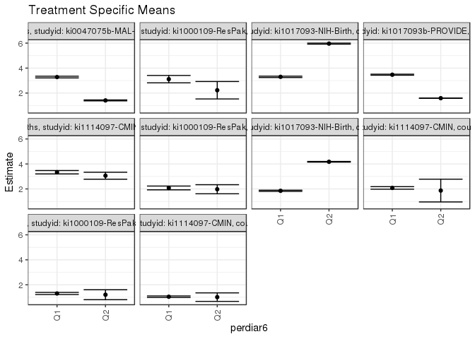

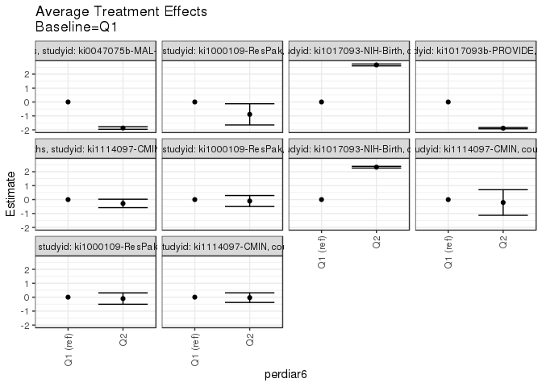

## Results Table

### Parameter: TSM

| agecat | studyid | country | intervention_level | baseline_level | estimate | ci_lower | ci_upper |
| --- | --- | --- | --- | --- | --- | --- | --- |
| 0-3 months | ki0047075b-MAL-ED | PERU | Q1 | NA | 3.281955 | 3.2138663 | 3.350043 |
| 0-3 months | ki0047075b-MAL-ED | PERU | Q2 | NA | 1.412235 | 1.3756251 | 1.448844 |
| 0-3 months | ki1000109-ResPak | PAKISTAN | Q1 | NA | 3.116052 | 2.8202873 | 3.411817 |
| 0-3 months | ki1000109-ResPak | PAKISTAN | Q2 | NA | 2.227897 | 1.5286561 | 2.927138 |
| 0-3 months | ki1017093-NIH-Birth | BANGLADESH | Q1 | NA | 3.300922 | 3.2459000 | 3.355943 |
| 0-3 months | ki1017093-NIH-Birth | BANGLADESH | Q2 | NA | 5.961094 | 5.9193240 | 6.002865 |
| 0-3 months | ki1017093b-PROVIDE | BANGLADESH | Q1 | NA | 3.470562 | 3.4293260 | 3.511798 |
| 0-3 months | ki1017093b-PROVIDE | BANGLADESH | Q2 | NA | 1.590709 | 1.5790091 | 1.602408 |
| 0-3 months | ki1114097-CMIN | PERU | Q1 | NA | 3.336728 | 3.2006313 | 3.472824 |
| 0-3 months | ki1114097-CMIN | PERU | Q2 | NA | 3.058123 | 2.7793606 | 3.336885 |
| 3-6 months | ki1000109-ResPak | PAKISTAN | Q1 | NA | 2.078212 | 1.9272251 | 2.229199 |
| 3-6 months | ki1000109-ResPak | PAKISTAN | Q2 | NA | 1.974039 | 1.6105454 | 2.337533 |
| 3-6 months | ki1017093-NIH-Birth | BANGLADESH | Q1 | NA | 1.848931 | 1.7995453 | 1.898317 |
| 3-6 months | ki1017093-NIH-Birth | BANGLADESH | Q2 | NA | 4.174948 | 4.1476576 | 4.202239 |
| 3-6 months | ki1114097-CMIN | GUINEA-BISSAU | Q1 | NA | 2.079644 | 1.9773133 | 2.181976 |
| 3-6 months | ki1114097-CMIN | GUINEA-BISSAU | Q2 | NA | 1.869825 | 0.9578487 | 2.781800 |
| 6-12 months | ki1000109-ResPak | PAKISTAN | Q1 | NA | 1.303353 | 1.2185380 | 1.388168 |
| 6-12 months | ki1000109-ResPak | PAKISTAN | Q2 | NA | 1.203726 | 0.8052678 | 1.602184 |
| 6-12 months | ki1114097-CMIN | GUINEA-BISSAU | Q1 | NA | 1.043141 | 0.9815645 | 1.104717 |
| 6-12 months | ki1114097-CMIN | GUINEA-BISSAU | Q2 | NA | 1.010533 | 0.6691827 | 1.351884 |

### Parameter: E(Y)

| agecat | studyid | country | intervention_level | baseline_level | estimate | ci_lower | ci_upper |
| --- | --- | --- | --- | --- | --- | --- | --- |
| 0-3 months | ki0047075b-MAL-ED | PERU | NA | NA | 3.315860 | 3.2526447 | 3.379076 |
| 0-3 months | ki1000109-ResPak | PAKISTAN | NA | NA | 3.073862 | 2.7876913 | 3.360033 |
| 0-3 months | ki1017093-NIH-Birth | BANGLADESH | NA | NA | 3.312925 | 3.2581305 | 3.367720 |
| 0-3 months | ki1017093b-PROVIDE | BANGLADESH | NA | NA | 3.482671 | 3.4434873 | 3.521854 |
| 0-3 months | ki1114097-CMIN | PERU | NA | NA | 3.315551 | 3.1827969 | 3.448305 |
| 3-6 months | ki1000109-ResPak | PAKISTAN | NA | NA | 2.069423 | 1.9275918 | 2.211255 |
| 3-6 months | ki1017093-NIH-Birth | BANGLADESH | NA | NA | 1.832691 | 1.7846731 | 1.880710 |
| 3-6 months | ki1114097-CMIN | GUINEA-BISSAU | NA | NA | 2.072970 | 1.9687527 | 2.177187 |
| 6-12 months | ki1000109-ResPak | PAKISTAN | NA | NA | 1.296473 | 1.2129800 | 1.379966 |
| 6-12 months | ki1114097-CMIN | GUINEA-BISSAU | NA | NA | 1.041590 | 0.9802963 | 1.102883 |

### Parameter: ATE

| agecat | studyid | country | intervention_level | baseline_level | estimate | ci_lower | ci_upper |
| --- | --- | --- | --- | --- | --- | --- | --- |
| 0-3 months | ki0047075b-MAL-ED | PERU | Q1 | Q1 | 0.0000000 | 0.0000000 | 0.0000000 |
| 0-3 months | ki0047075b-MAL-ED | PERU | Q2 | Q1 | -1.8697200 | -1.9577854 | -1.7816546 |
| 0-3 months | ki1000109-ResPak | PAKISTAN | Q1 | Q1 | 0.0000000 | 0.0000000 | 0.0000000 |
| 0-3 months | ki1000109-ResPak | PAKISTAN | Q2 | Q1 | -0.8881551 | -1.6485450 | -0.1277651 |
| 0-3 months | ki1017093-NIH-Birth | BANGLADESH | Q1 | Q1 | 0.0000000 | 0.0000000 | 0.0000000 |
| 0-3 months | ki1017093-NIH-Birth | BANGLADESH | Q2 | Q1 | 2.6601727 | 2.5921446 | 2.7282007 |
| 0-3 months | ki1017093b-PROVIDE | BANGLADESH | Q1 | Q1 | 0.0000000 | 0.0000000 | 0.0000000 |
| 0-3 months | ki1017093b-PROVIDE | BANGLADESH | Q2 | Q1 | -1.8798534 | -1.9258463 | -1.8338606 |
| 0-3 months | ki1114097-CMIN | PERU | Q1 | Q1 | 0.0000000 | 0.0000000 | 0.0000000 |
| 0-3 months | ki1114097-CMIN | PERU | Q2 | Q1 | -0.2786049 | -0.5811673 | 0.0239574 |
| 3-6 months | ki1000109-ResPak | PAKISTAN | Q1 | Q1 | 0.0000000 | 0.0000000 | 0.0000000 |
| 3-6 months | ki1000109-ResPak | PAKISTAN | Q2 | Q1 | -0.1041728 | -0.4976591 | 0.2893136 |
| 3-6 months | ki1017093-NIH-Birth | BANGLADESH | Q1 | Q1 | 0.0000000 | 0.0000000 | 0.0000000 |
| 3-6 months | ki1017093-NIH-Birth | BANGLADESH | Q2 | Q1 | 2.3260173 | 2.2650436 | 2.3869910 |
| 3-6 months | ki1114097-CMIN | GUINEA-BISSAU | Q1 | Q1 | 0.0000000 | 0.0000000 | 0.0000000 |
| 3-6 months | ki1114097-CMIN | GUINEA-BISSAU | Q2 | Q1 | -0.2098199 | -1.1279442 | 0.7083044 |
| 6-12 months | ki1000109-ResPak | PAKISTAN | Q1 | Q1 | 0.0000000 | 0.0000000 | 0.0000000 |
| 6-12 months | ki1000109-ResPak | PAKISTAN | Q2 | Q1 | -0.0996267 | -0.5069239 | 0.3076705 |
| 6-12 months | ki1114097-CMIN | GUINEA-BISSAU | Q1 | Q1 | 0.0000000 | 0.0000000 | 0.0000000 |
| 6-12 months | ki1114097-CMIN | GUINEA-BISSAU | Q2 | Q1 | -0.0326073 | -0.3784801 | 0.3132655 |